# WP1: Simple View - Focusing on shape over level - Subsample B

30/09/2021

This script is used for running the mixture models, with an attempt to identify reading profile differences in shape rather than just level. This process is exploratory and was not pre-registered (the original pre-registration can be found [here](https://osf.io/4zahf)).

The models are based on those proposed by [Morin & Marsh (2015)](https://www.tandfonline.com/doi/pdf/10.1080/10705511.2014.919825). The models were initially run on the “exploratory” or “calibration” half of the dataset (subsample A; **WP1_SimpView_LPA_shape.Rmd**), but the best model selected showed a significantly poorer fit when fitted with subsample B (**WP1_SimpView_ShapeValidation.Rmd**)—although the profiles looked similar in shape. This script repeats the class enumeration process with subsample B, to ensure that we have selected the best model specification overall.

# Set-up

## Libraries

*Package versions were up-to-date as of 12/08/2021. Version information can be found at the end of the output file.*

*Models were run using Mplus Version 8.5.*

```r
# Specify packages
pkgs <- c("tidyverse", "MplusAutomation", "texreg", "DiagrammeR", "kableExtra", "ggalluvial", "scales", "rlist")

# Load all packages
invisible(lapply(pkgs, library, character.only = TRUE))
```

## Directories

```r
# Create subdirectories for storing mplus scripts, data files, and output, if do not already exist
if(dir.exists("./mplus_models/")==FALSE){dir.create("./mplus_models/")}
if(dir.exists("./mplus_models/simpview/")==FALSE){dir.create("./mplus_models/simpview/")}
if(dir.exists("./mplus_models/simpview/shapeB")==FALSE){dir.create("./mplus_models/simpview/shapeB")}
if(dir.exists("../output/")==FALSE){dir.create("../output/")}
if(dir.exists("../output/figures")==FALSE){dir.create("../output/figures")}
if(dir.exists("../output/tables")==FALSE){dir.create("../output/tables")}
```

## Functions

Functions for processing the output are stored in a separate script.

```r
source("WP1_OutputFunctions.R")
```

## Data

This analysis is developed on half of the dataset, for subsequent cross-validation with the remaining half (WP1_SimpView_CrossValidation.Rmd).

```r
sv_data <- read.csv("../data/processed/WP1_data_subB.csv")  %>%       # ALSPAC data

  # Select and format relevant variables
  select(yp_id, cidB3153, age_m_f8, age_m_f9,
                nara_acc_raw_f9, read_word_raw_f9, read_nonw_raw_f9,  # reading accuracy variables
                nara_comp_raw_f9, wold_comp_raw_f8) %>%               # comprehension variables
  mutate(combAcc = read_word_raw_f9 + read_nonw_raw_f9) %>%           # create combined item accuracy score
  select(-read_word_raw_f9, -read_nonw_raw_f9) %>%                    # remove other measures

  # Rename for Mplus character limit
  rename(naraComp = nara_comp_raw_f9,
         naraAcc = nara_acc_raw_f9,
         woldComp = wold_comp_raw_f8,
         f8age = age_m_f8,
         f9age = age_m_f9) %>%

  # Change ID to a factor
  mutate(yp_id = as.factor(yp_id))
```

# Class enumeration

**Aim: to fit mixture models with different numbers of classes, aimed at identifying reading profiles that vary in shape beyond differences in level (Morin & Marsh, 2015).**

As an exploratory process, we try fitting both Models 3 and 4 from Morin & Marsh (2015). In Model 3, differences in performance level are incorporated into the model using a single continuous latent variable, so that the level and shape of profiles are estimated *simultaneously* in a factor mixture model. In Model 4, global factor score is estimated separately and entered into the model as a control variable in a latent profile analysis, allowing for the estimation of differently shaped profiles *beyond* differences in performance level.

## Set-up

*Note: Models were edited to increase starts if best log-likelihood value not replicated. Initial plan to increase to 2000 200 (Lubke & Luningham, 2017), but increased further where necessary.*

Create base model with basic set-up, including age covariates. Specify other model elements for use in different models.

```r
# Create base model
m_base <- mplusObject(
  TITLE = "Latent Profile Analysis;",
  ANALYSIS = "estimator = mlr; type = mixture; starts = 500 50;
              processors = 4(STARTS);",
  VARIABLE = "idvariable = cidB3153; classes = c(1);",
  MODEL = "%OVERALL%
           f8age; f9age;
           combAcc naraAcc naraComp on f9age;
           woldcomp on f8age;",
  OUTPUT = "TECH1 TECH8;",
  PLOT = "TYPE = PLOT3;",
  usevariables = colnames(sv_data[,!names(sv_data) %in% c("yp_id")]),
  rdata = sv_data)

# Specify all variances - note this fixes naraAcc residual variance to 0 for the initial LPA model
vars <- "
  naraComp naraAcc@0 combAcc woldComp;"

# Specify all means
means <- "
  [naraComp naraAcc combAcc woldComp];"

# Specify all covariances
covars <- "
  naraComp with naraAcc;
  naraComp with combAcc;
  naraComp with woldComp;
  naraAcc with combAcc;
  naraAcc with woldComp;
  combAcc with woldComp;  "

# Specify no covariances
no_covars <- "
  naraComp with naraAcc@0;
  naraComp with combAcc@0;
  naraComp with woldComp@0;
  naraAcc with combAcc@0;
  naraAcc with woldComp@0;
  combAcc with woldComp@0;  "
```

## Model 3: Factor Mixture Model

Model 3 is a factor mixture model with a class-invariant higher order latent factor. The class-invariance of the factor allows for a measure of global ability across all measures, defined in the same way across all classes. We allowed for correlated errors between the comprehension variables in the global ability factor.

### Specification

**Steps 1-3)** Fit series of increasing *k*-class models.

*Note: Started by fitting up to 6-class models, but increased the number of classes after adjusted LRTs implied they might improve model fit.*

```r
# Fit initial models
m_fmm3 <- lapply(c(1:8), function(k) {

  # Update model spec 1: overall model estimates (global performance factor estimation)
  body <- update(m_base,
              MODEL = as.formula(sprintf("~ . + '%s \n %s
              G by combAcc* naraAcc naraComp woldComp;
              naraComp with woldComp;
              [G@0]; G@1;
              f8age with G@0; f9age with G@0;
              '", vars, means)))

  # Create class-level specifications (means and variances only)
  class_spec <- paste0("%c#1% \n ", vars, means)
  if (k > 1){
    for (i in 2:k){
      class_spec <- paste0(class_spec, "\n %c#", i, "% \n ", vars, means)
    }
  }

  # ...Update model spec 2: class estimates
  body <- update(body,
     TITLE = as.formula(sprintf("~ 'Model 3 (FMM): %d classes;'", k)),
     VARIABLE = as.formula(sprintf("~ 'idvariable = cidb3153; classes = c(%d);'", k)),
     MODEL = as.formula(sprintf("~ . + '%s'", class_spec)))

  # Run model
  mplusModeler(body, sprintf("mplus_models/simpview/shapeB/fmm3_%dclass.dat", k), run = FALSE)
 })

# Read in output
fmm3_out <- readModels(target = "./mplus_models/simpview/shapeB", filefilter = "(fmm3_)([1-8])")
```

*Note that the 6-class model LL was not replicated (tried up to 8000 2000 starts)*

Use optseed to compute adjusted LRT tests (Lo-Mendell-Rubin; Vuong-Lo-Mendell-Rubin). This was estimated after initial fitting for computational efficiency, and also to permit re-running of the test with increased k-1starts if the k-1 model does not have the same loglikelihood as the model fitted above ([Asparouhov & Muthen, 2012](https://www.statmodel.com/examples/webnotes/webnote14.pdf)).

```r
# # Read in output
fmm3_out <- readModels(target = "./mplus_models/simpview/shapeB", filefilter = "(fmm3_)([1-8])")

fmm3_lmr <- recomp_LMR(orig_mods = m_fmm3,
                        orig_output = fmm3_out,
                        mods = c(1:length(fmm3_out)),
                        #mods = c(7),
                        #kstarts = "500 50",
                        filepath = "mplus_models/simpview/shapeB",
                        rerun = FALSE
                        )

fmm_enum_table(fmm3_lmr, LMR_warn = TRUE) %>%
  select(Specification, Classes, LMR_check) %>%
  filter(!is.na(LMR_check))
```

```
##   Specification Classes            LMR_check
## 1                     2
## 2                     3
## 3                     4
## 4                     5 Re-run initial model
## 5                     6
## 6                     7           Re-run LMR
## 7                     8
```

*The k-1 model for the 5-class LMR test did not match the LL achieved by the 4-class model initially fit, but this could not be resolved. The 6- and 7- class tests can also not be relied upon, given that the 6-class model suffered issues of local maxima that could not be resolved. We take these issues to indicate that these model specifications are not well suited to the data—in line with our previous findings with subsample A that profiles were arbitrarily formed at different levels of ability.*

### Indices

**Steps 4-5)** Extract fit indices, and use to select smaller subset of candidate models.

```r
# Read in output
fmm3_lmr <- readModels(target = "./mplus_models/simpview/shapeB", filefilter = "(fmm3_lmr_)([1-8])")

# Print table
fmm3_summary <- lpa_enum_table(output = fmm3_lmr) %>%
  mutate(Specification = "Shape FMM")
fmm3_summary %>% kable("pipe")
```

| Specification | Classes | LL | Parameters | BIC | CAIC | AWE | VLMR_p | LMR_p | BF | cmP_k |
| --- | --- | --- | --- | --- | --- | --- | --- | --- | --- | --- |
| Shape FMM | 1 | -56606.66 | 21 | 113384.2 | 113405.2 | 113415.7 | NA | NA | NA | 0.00 |
| Shape FMM | 2 | -55572.40 | 31 | 111397.1 | 111428.1 | 111443.6 | <0.01 | <0.01 | >100 | 0.00 |
| Shape FMM | 3 | -55340.58 | 41 | 111014.8 | 111055.8 | 111076.3 | <0.01 | <0.01 | >100 | 0.00 |
| Shape FMM | 4 | -55099.23 | 51 | 110613.5 | 110664.5 | 110690.0 | <0.01 | <0.01 | >100 | 0.00 |
| Shape FMM | 5 | -54875.34 | 61 | 110247.1 | 110308.1 | 110338.6 | <0.01 | <0.01 | >100 | 0.00 |
| Shape FMM | 6 | -54810.25 | 71 | 110198.3 | 110269.3 | 110304.8 | 0.39 | 0.39 | >100 | 0.00 |
| Shape FMM | 7 | -54764.36 | 81 | 110187.9 | 110268.9 | 110309.4 | 0.22 | 0.23 | >100 | 0.01 |
| Shape FMM | 8 | -54719.23 | 91 | 110179.1 | 110270.1 | 110315.6 | <0.01 | <0.01 | 84.06 | 0.99 |

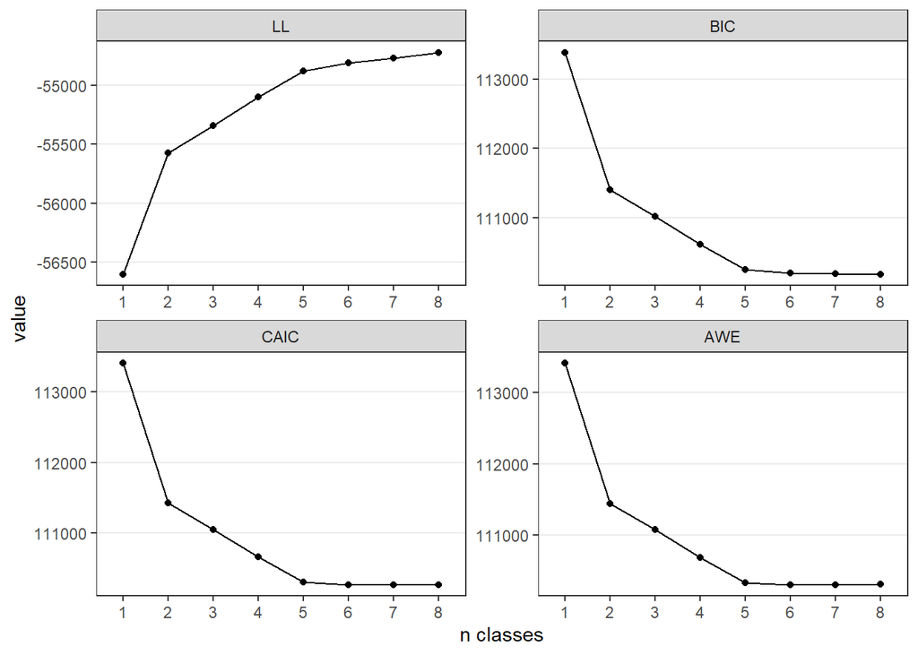

```r
# Elbow plots for information criteria
lpa_enum_elbow(fmm3_summary)  # use the same metrics for comparison as LPA model
```

### Inspection

**Step 6)** View classification diagnostics for candidate models. Can also inspect how the classes correspond across models.

```r
# Extract participant level data
fmm3_cand <- mm_extract_data(orig_mods = m_fmm3, orig_output = fmm3_out,
                               candidate_mods = c(3,5),
                               filepath = "mplus_models/simpview/shapeB",
                               lrtstarts = "0 0 0 0", # bLRTs removed from process after previous issues
                               rerun = FALSE, optseed = TRUE,
                               one_fit = TRUE)

# Print table, and append bLRT values to main output
fmm3_summary %>% kable("pipe")
```

| Specification | Classes | LL | Parameters | BIC | CAIC | AWE | VLMR_p | LMR_p | BF | cmP_k |
| --- | --- | --- | --- | --- | --- | --- | --- | --- | --- | --- |
| Shape FMM | 1 | -56606.66 | 21 | 113384.2 | 113405.2 | 113415.7 | NA | NA | NA | 0.00 |
| Shape FMM | 2 | -55572.40 | 31 | 111397.1 | 111428.1 | 111443.6 | <0.01 | <0.01 | >100 | 0.00 |
| Shape FMM | 3 | -55340.58 | 41 | 111014.8 | 111055.8 | 111076.3 | <0.01 | <0.01 | >100 | 0.00 |
| Shape FMM | 4 | -55099.23 | 51 | 110613.5 | 110664.5 | 110690.0 | <0.01 | <0.01 | >100 | 0.00 |
| Shape FMM | 5 | -54875.34 | 61 | 110247.1 | 110308.1 | 110338.6 | <0.01 | <0.01 | >100 | 0.00 |
| Shape FMM | 6 | -54810.25 | 71 | 110198.3 | 110269.3 | 110304.8 | 0.39 | 0.39 | >100 | 0.00 |
| Shape FMM | 7 | -54764.36 | 81 | 110187.9 | 110268.9 | 110309.4 | 0.22 | 0.23 | >100 | 0.01 |
| Shape FMM | 8 | -54719.23 | 91 | 110179.1 | 110270.1 | 110315.6 | <0.01 | <0.01 | 84.06 | 0.99 |

```r
# Compute classification diagnostics
class_diag(fmm3_cand)
```

```
## [1] "CLASSIFICATION DIAGNOSTICS FOR "
## [1] "3-class model"
## [1] "Entropy: 0.834"
##
## [1] "Average posterior class probability:"
##     1     2     3
## 0.843 0.789 0.964
##
## [1] "Odds of correct classification ratio:"
##  1  2  3
## 63 19  9
## [1] "Good class separation and assignment accuracy (Nagin, 2005)"
##
## [1] "Model estimated proportion for each class:"
## [1] 0.07895 0.16688 0.75416
##
## [1] "Proportion modally assigned to each class:"
## [1] 0.07216 0.15630 0.77155
##
## [1] "--------------------------------------------"
##
## [1] "CLASSIFICATION DIAGNOSTICS FOR "
## [1] "5-class model"
## [1] "Entropy: 0.854"
##
## [1] "Average posterior class probability:"
##     1     2     3     4     5
## 0.781 0.961 0.849 0.758 0.771
##
## [1] "Odds of correct classification ratio:"
##   1   2   3   4   5
##  21  10 116  47  84
## [1] "Good class separation and assignment accuracy (Nagin, 2005)"
##
## [1] "Model estimated proportion for each class:"
## [1] 0.14693 0.70595 0.04636 0.06211 0.03864
##
## [1] "Proportion modally assigned to each class:"
## [1] 0.13877 0.73035 0.04674 0.05171 0.03243
##
## [1] "--------------------------------------------"
```

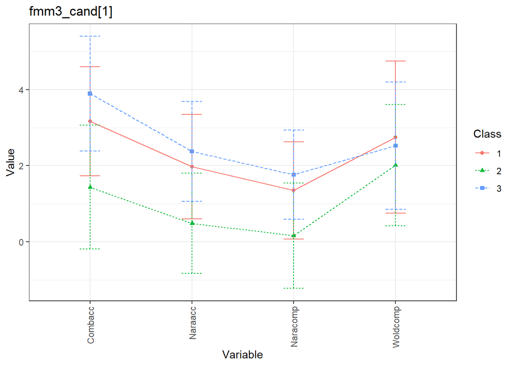

```r
# Plot class means
plotMixtures_simpView(fmm3_cand[1])
```

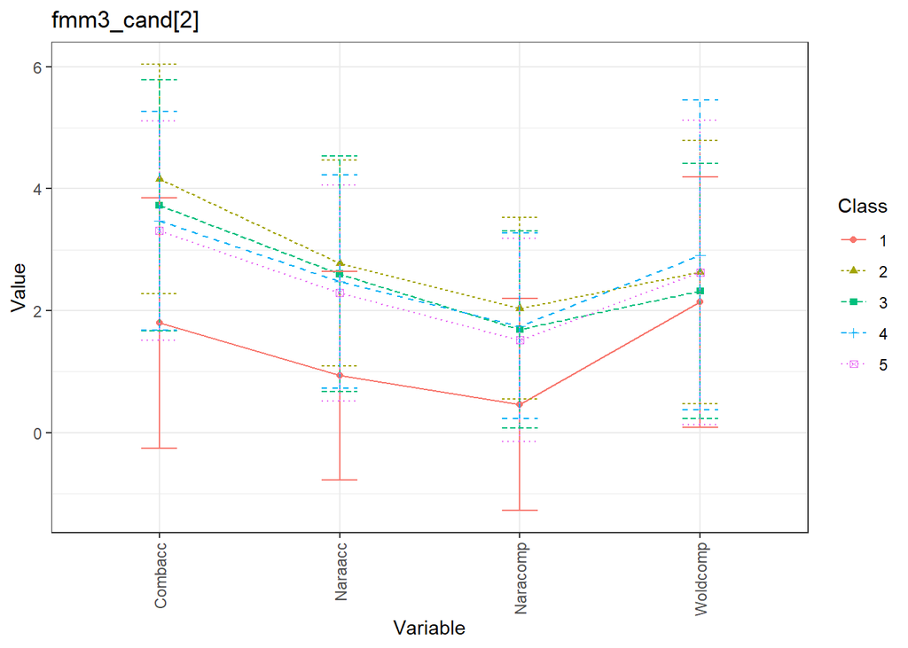

```r
plotMixtures_simpView(fmm3_cand[2])
```

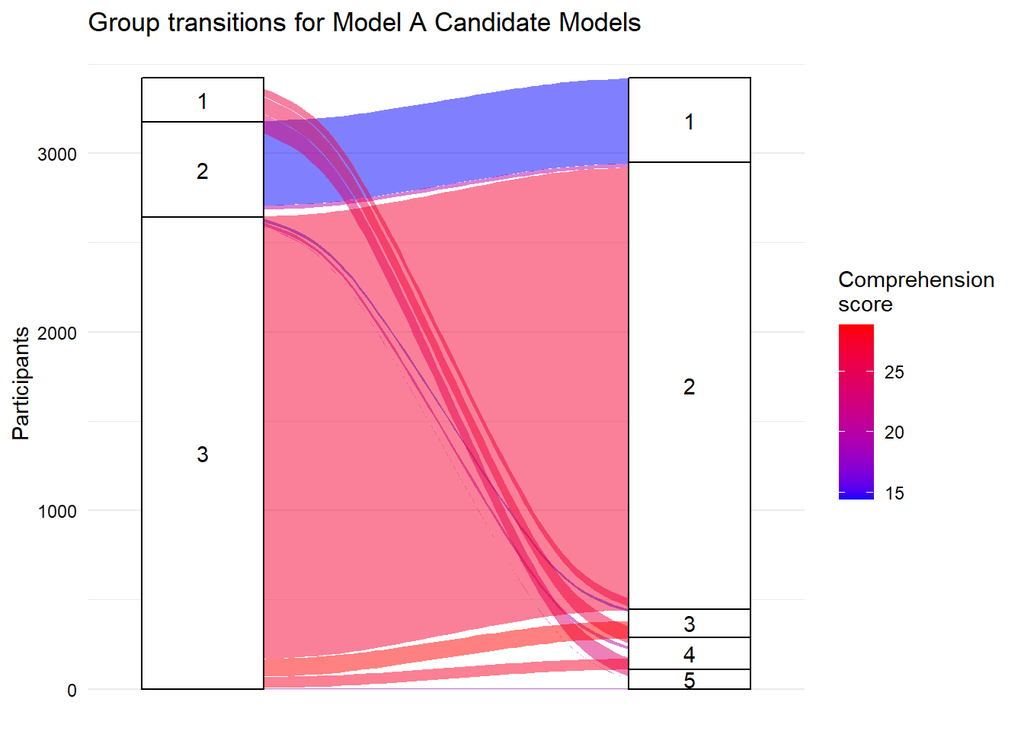

```r
# Inspect transitions
extract_classes(fmm3_cand, type = "lpa")
```

**Comments:**

- **Classification diagnostics:** Both models have good assignment accuracy, 5-class model has higher entropy.
- **Interpretability:** Neither model succeeded in differentiating profiles of different shapes (i.e., dissociated strengths and weaknesses in decoding and comprehension skills); neither stand out as the key best choice. Select 5-class model on basis of fit indices.

### Selection

**Step 7)** Select final model in class enumeration process, for Model 3.

```r
fmm3_final_nclass <- 5
fmm3_final_m <- fmm3_cand$sv_fmm3_rerun_5class.out
```

## Model 4: LPA with global covariate

In this model, the global factor score is estimated separately and entered into the model as a control variable on the measures, leaving the residuals of those predictions for the class estimates. Thus, overall ability is treated as a bias, and the classes extract profile shape beyond overall ability.

### Global factor scores

First check that model with correlated errors for the comprehension tasks still an appropriate model for this subsample.

```r
# Run single factor model (including age covariates)
m_cfa <- mplusObject(
  TITLE = "Confirmatory Factor Analysis - Extract factor scores;",
  ANALYSIS = "estimator = mlr; type = general;",
  MODEL = "f8age; f9age;
           G by combAcc naraAcc naraComp woldComp;
           combAcc naraAcc naraComp on f9age;
           woldComp on f8age;",
  VARIABLE = "idvariable = cidB3153;",
  OUTPUT = "sampstat; TECH1; TECH4; stdyx; modindices; ",
  PLOT = "TYPE = PLOT3;",
  usevariables = c("cidB3153", "naraComp", "naraAcc", "combAcc", "woldComp", "f8age", "f9age"),
  rdata = sv_data,
  SAVEDATA = "FILE IS shape_cfa_scores.dat; SAVE = fscores;")

m_cfa_fit <- mplusModeler(m_cfa,
                           modelout = "./mplus_models/simpview/shapeB/cfa_scores1.inp",
                           check = TRUE, run = FALSE)
```

```
## All ok
```

```r
# Fit model with additional covariance between the comprehension measures (theoretically sound)
m_cfa1m <- update(m_cfa,
                 TITLE = ~ "Confirmatory Factor Analysis - modification1 comprehension tasks;",
                 MODEL = ~. + "woldComp with naraComp;",
                 SAVEDATA = ~ "FILE IS shape_cfa_scores2.dat; SAVE = fscores;")

m_cfa1m_fit <- mplusModeler(m_cfa1m,
                           modelout = "./mplus_models/simpview/shapeB/cfa_scores2.inp",
                           check = TRUE, run = FALSE)
```

```
## All ok
```

```r
# Inspect model outputs
cfa_out <- readModels(target = "./mplus_models/simpview/shapeB", filefilter = "cfa")
SummaryTable(cfa_out, keepCols = c("Title", "Parameters", "LL", "CFI", "TLI", "AIC", "BIC", "RMSEA_Estimate", "RMSEA_pLT05", "SRMR"))
```

```
##                                                                Title Parameters
## 1              Confirmatory Factor Analysis - Extract factor scores;         23
## 2  Confirmatory Factor Analysis - modification1 comprehension tasks;         24
##          LL   CFI   TLI      AIC      BIC RMSEA_Estimate RMSEA_pLT05  SRMR
## 1 -56756.93 0.956 0.845 113559.9 113701.1          0.160       0.000 0.031
## 2 -56586.08 0.999 0.996 113220.2 113367.5          0.027       0.981 0.007
```

```r
# The modified CFA is a much better fit, and good fit overall - use these scores for analysis
g_data <- as.data.frame(cfa_out$cfa_scores2.out$savedata) %>%
  select(-G_SE)
```

### Specification

**Steps 1-3)** Fit series of increasing *k*-class models.

```r
# Re-add naraAcc variance
vars <- "
  naraComp naraAcc combAcc woldComp;"

# Fit models
m_lpa4 <- lapply(1:8, function(k) {

  # Update model spec 1: overall model estimates (variances and covariances)
  body <- update(m_base,
              MODEL = as.formula(sprintf("~ . + '%s \n %s
              combAcc naraAcc naraComp woldComp ON G;
              %s'", vars, means, no_covars)))

  # Create class-level specifications (variances only)
  class_spec <- paste0("%c#1% \n ", vars, means)
  if (k > 1){
    for (i in 2:k){
      class_spec <- paste0(class_spec, "\n %c#", i, "% \n ", vars, means)
    }
  }

  # ...Update model spec 2: class estimates
  body <- update(body,
     TITLE = as.formula(sprintf("~ 'Model 4 (LPA and G covariate): %d classes;'", k)),
     VARIABLE = as.formula(sprintf("~ 'idvariable = cidb3153; classes = c(%d);'", k)),
     MODEL = as.formula(sprintf("~ . + '%s'", class_spec)),
     rdata = g_data,
     usevariables = names(g_data))

  # Run model
  mplusModeler(body, sprintf("mplus_models/simpview/shapeB/lpa4_%dclass.dat", k), run = FALSE)
 })

# Read in output
lpa4_out <- readModels(target = "./mplus_models/simpview/shapeB", filefilter = "(lpa4_)([1-9])")
```

Use optseed to compute adjusted LRT tests (Lo-Mendell-Rubin; Vuong-Lo-Mendell-Rubin). This was estimated after initial fitting for computational efficiency, and also to permit re-running of the test with increased k-1starts if the k-1 model does not have the same loglikelihood as the model fitted above ([Asparouhov & Muthen, 2012](https://www.statmodel.com/examples/webnotes/webnote14.pdf)).

```r
lpa4_lmr <- recomp_LMR(orig_mods = m_lpa4,
                        orig_output = lpa4_out,
                        mods = c(1:length(lpa4_out)),
                        #mods = c(7),
                        #kstarts = "10000 2500",
                        filepath = "mplus_models/simpview/shapeB",
                        rerun = FALSE
                        )

# Check that LL of k-1 model in LMR test matches LL of initial model fit
lpa_enum_table(lpa4_lmr, LMR_warn = TRUE) %>%
  select(Specification, Classes, LMR_check)
```

```
##   Specification Classes  LMR_check
## 1                     1       <NA>
## 2                     2
## 3                     3
## 4                     4
## 5                     5
## 6                     6
## 7                     7 Re-run LMR
## 8                     8
```

*Note that the 7-class LMR test is not accurate (tried re-running up to 10000 starts)*

### Indices

**Steps 4-5)** Extract fit indices, and use to select smaller subset of candidate models.

```r
# Read in output
lpa4_lmr <- readModels(target = "./mplus_models/simpview/shapeB", filefilter = "(lpa4_lmr_)([1-9])")

# Print table
lpa4_summary <- lpa_enum_table(output = lpa4_lmr) %>%
  mutate(Specification = "Shape LPA")
lpa4_summary %>%kable("pipe")
```

| Specification | Classes | LL | Parameters | BIC | CAIC | AWE | VLMR_p | LMR_p | BF | cmP_k |
| --- | --- | --- | --- | --- | --- | --- | --- | --- | --- | --- |
| Shape LPA | 1 | -47188.91 | 21 | 94548.73 | 94569.73 | 94580.23 | NA | NA | NA | 0 |
| Shape LPA | 2 | -46154.49 | 32 | 92569.40 | 92601.40 | 92617.40 | <0.01 | <0.01 | >100 | 0 |
| Shape LPA | 3 | -45348.61 | 43 | 91047.17 | 91090.17 | 91111.67 | <0.01 | <0.01 | >100 | 0 |
| Shape LPA | 4 | -44879.47 | 54 | 90198.41 | 90252.41 | 90279.41 | 0.01 | 0.01 | >100 | 0 |
| Shape LPA | 5 | -44486.31 | 65 | 89501.60 | 89566.60 | 89599.10 | 0.03 | 0.03 | >100 | 0 |
| Shape LPA | 6 | -44161.68 | 76 | 88941.87 | 89017.87 | 89055.87 | 0.13 | 0.13 | >100 | 0 |
| Shape LPA | 7 | -43882.22 | 87 | 88472.47 | 88559.47 | 88602.97 | 0.18 | 0.18 | >100 | 0 |
| Shape LPA | 8 | -43681.29 | 98 | 88160.13 | 88258.13 | 88307.13 | 0.60 | 0.60 | >100 | 1 |

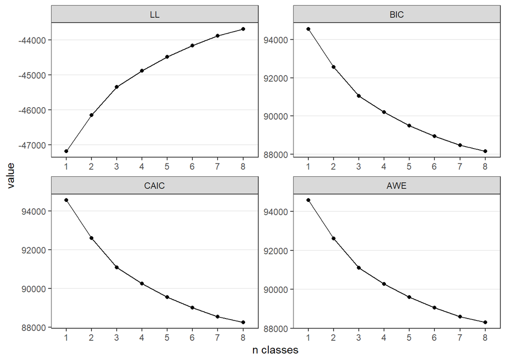

```r
# Elbow plots for information criteria
lpa_enum_elbow(lpa4_summary)# benchmark_stats = lpa_benchmark)
```

Best model for:

**a) Absolute fit** (fewest classes with better LL than benchmark)**:**  
**b) Information heuristics** (diminishing gains from elbow plots)**:** *Not clear, possibly 3 but substantial improvements beyond*  
**c) Adjusted LRTs** (fewest classes not sig improved by additional classes)**:** *5-class*  
**d) Approximate BF** (fewest classes with moderate-strong evidence compared to next model): *NA/8-class*  
**e) Approximate correct model probability:** *NA/8-class*

### Inspection

**Step 6)** View classification diagnostics for candidate models.

```r
# Extract participant level data
lpa4_cand <- mm_extract_data(orig_mods = m_lpa4, orig_output = lpa4_out,
                               candidate_mods = c(5:6),
                               filepath = "mplus_models/simpview/shapeB",
                               lrtstarts = "0 0 0 0",  # remove bLRT given previous issues
                               rerun = FALSE, optseed = TRUE,
                               one_fit = TRUE)

#Print table, and append bLRT values to main output
lpa4_summary <- add_bLRT(lpa4_cand, lpa4_summary)
lpa4_summary %>% kable("pipe")
```

| Specification | Classes | Parameters | LL | BIC | CAIC | AWE | VLMR_p | LMR_p | bLRT_p | BF | cmP_k |
| --- | --- | --- | --- | --- | --- | --- | --- | --- | --- | --- | --- |
| Shape LPA | 1 | 21 | -47188.91 | 94548.73 | 94569.73 | 94580.23 | NA | NA | NA | NA | 0 |
| Shape LPA | 2 | 32 | -46154.49 | 92569.40 | 92601.40 | 92617.40 | <0.01 | <0.01 | NA | >100 | 0 |
| Shape LPA | 3 | 43 | -45348.61 | 91047.17 | 91090.17 | 91111.67 | <0.01 | <0.01 | NA | >100 | 0 |
| Shape LPA | 4 | 54 | -44879.47 | 90198.41 | 90252.41 | 90279.41 | 0.01 | 0.01 | NA | >100 | 0 |
| Shape LPA | 5 | 65 | -44486.31 | 89501.60 | 89566.60 | 89599.10 | 0.03 | 0.03 | NA | >100 | 0 |
| Shape LPA | 6 | 76 | -44161.68 | 88941.87 | 89017.87 | 89055.87 | 0.13 | 0.13 | NA | >100 | 0 |
| Shape LPA | 7 | 87 | -43882.22 | 88472.47 | 88559.47 | 88602.97 | 0.18 | 0.18 | NA | >100 | 0 |
| Shape LPA | 8 | 98 | -43681.29 | 88160.13 | 88258.13 | 88307.13 | 0.60 | 0.60 | NA | >100 | 1 |

```r
# Compute classification diagnostics
class_diag(lpa4_cand)
```

```
## [1] "CLASSIFICATION DIAGNOSTICS FOR "
## [1] "5-class model"
## [1] "Entropy: 0.786"
##
## [1] "Average posterior class probability:"
##     1     2     3     4     5
## 0.891 0.859 0.831 0.876 0.848
##
## [1] "Odds of correct classification ratio:"
##  1  2  3  4  5
## 22 78 19 26 18
## [1] "Good class separation and assignment accuracy (Nagin, 2005)"
##
## [1] "Model estimated proportion for each class:"
## [1] 0.27108 0.07278 0.20901 0.21111 0.23602
##
## [1] "Proportion modally assigned to each class:"
## [1] 0.26585 0.06807 0.21531 0.20421 0.24657
##
## [1] "--------------------------------------------"
##
## [1] "CLASSIFICATION DIAGNOSTICS FOR "
## [1] "6-class model"
## [1] "Entropy: 0.798"
##
## [1] "Average posterior class probability:"
##     1     2     3     4     5     6
## 0.894 0.867 0.844 0.847 0.859 0.829
##
## [1] "Odds of correct classification ratio:"
##  1  2  3  4  5  6
## 34 22 25 31 81 24
## [1] "Good class separation and assignment accuracy (Nagin, 2005)"
##
## [1] "Model estimated proportion for each class:"
## [1] 0.19813 0.23155 0.17880 0.15232 0.07005 0.16915
##
## [1] "Proportion modally assigned to each class:"
## [1] 0.19573 0.24277 0.18084 0.14665 0.06486 0.16915
##
## [1] "--------------------------------------------"
```

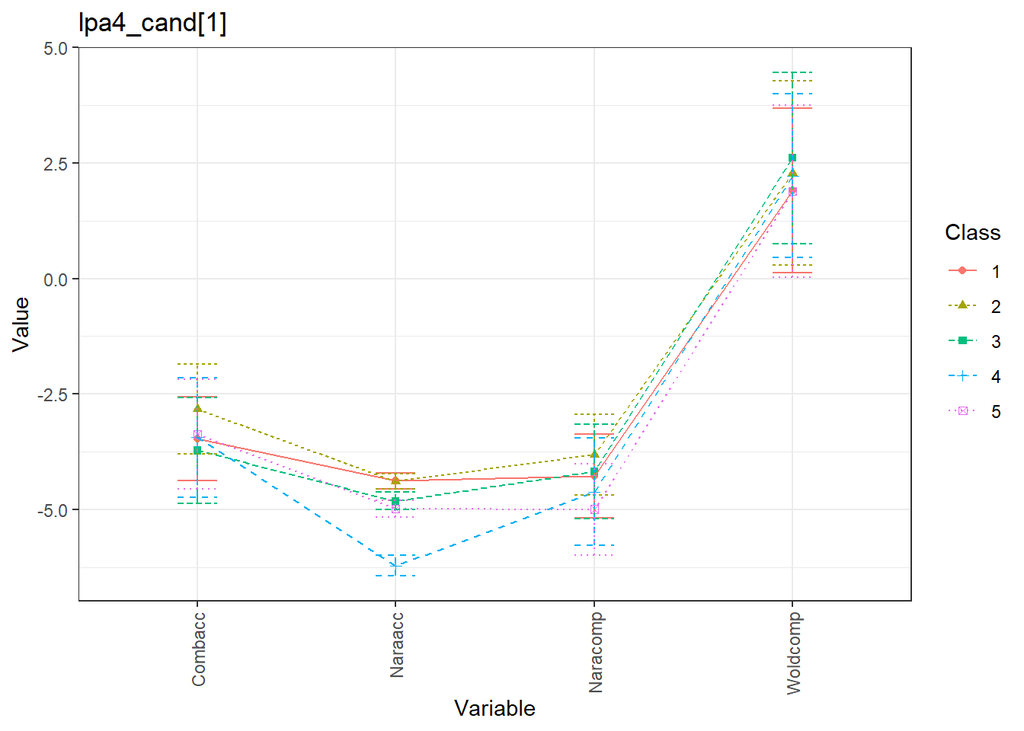

```r
# Plot class means
plotMixtures_simpView(lpa4_cand[1])
```

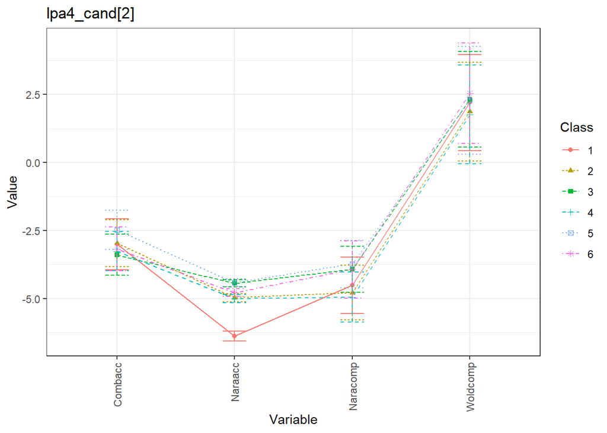

```r
plotMixtures_simpView(lpa4_cand[2])
```

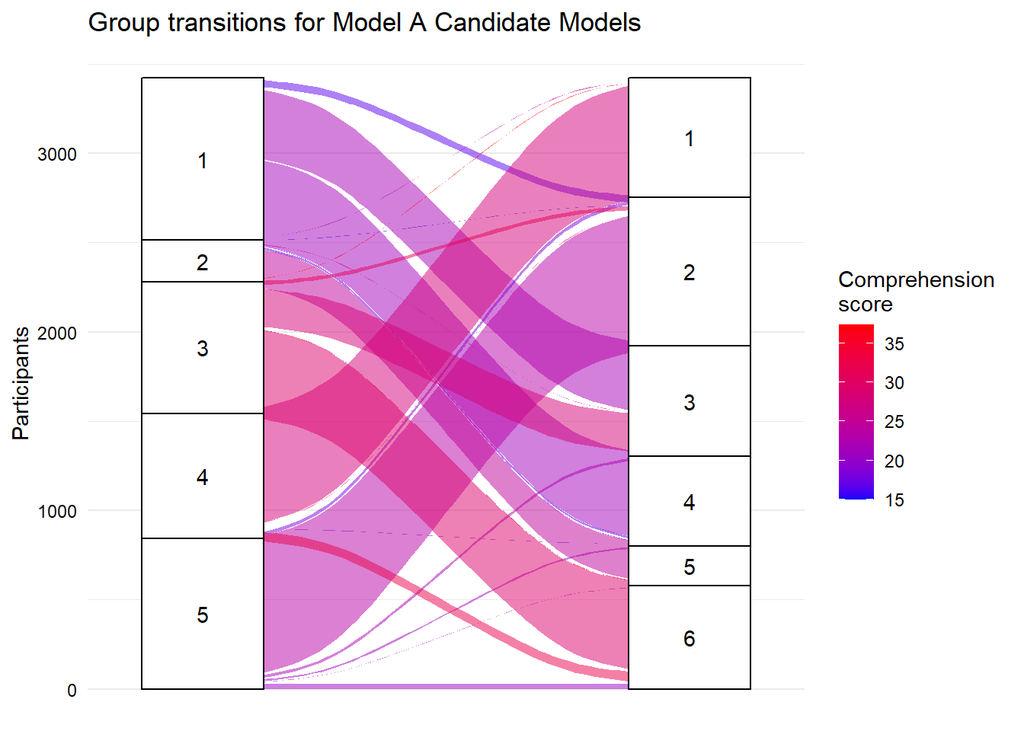

```r
# Inspect transitions
extract_classes(lpa4_cand, type = "lpa")
```

Comments:

- **Classification diagnostics:** Both have good classification diagnostics, no problems with very small classes. Entropy slightly higher in higher-class model.
- **Interpretability:** The two models show differentiation by shape, although with less stability in profiles between models than was seen for sub-sample A. Although the 5-class model is favoured by the LMR tests, the addition of classes beyond this still show continued improvements in the fit indices. The 5-class model does not succeed in identifying a poor comprehender group—our theoretical focus—and the profiles do not correspond as well to the 5-class model fitted on subsample A. In contrast, the 6-class model shows very similar profiles to those identified initially, including a poor comprehender group, suggesting that this model is both relatively stable and well-aligned with our theoretical motivation.

### Selection

**Step 7)** Select final model in class enumeration process, for model specification B.

```r
lpa4_final_nclass <- 6
lpa4_final_m <- lpa4_cand$sv_lpa4_rerun_6class.out
```